# Website Redesign Analysis

Nikhil Devireddy

2025-09-28

```r
url <- "https://www.mclaren.com/racing/formula-1/"   # change to any webpage you want
shot <- "webpage_shot.png"

webshot(url, file = shot, vwidth = 1600, vheight = 1000, cliprect = "viewport")
```

```
## https://www.mclaren.com/racing/formula-1/ screenshot completed
```

[figure not shown]

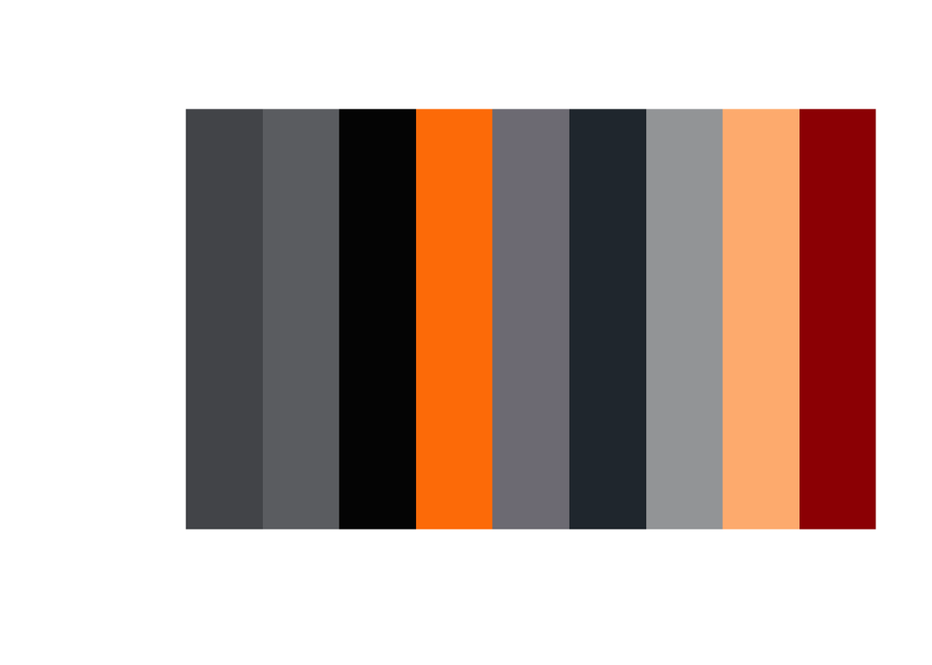

```
##  [1] "#FFFFFF" "#53565A" "#6D6F73" "#030303" "#FF8000" "#7F7E85" "#29333B"
##  [8] "#A3A5A7" "#FFB980" "#9E0101"
```

```r
cols <- get_colors(shot)

make_palette(cols)
```

```r
top_hex <- cols %>%
  arrange(desc(col_freq)) %>%
  pull(col_hex) %>%
  unique()

cat_pal <- c("Current"="#53565A", "Redesign"="#FF8000")
```

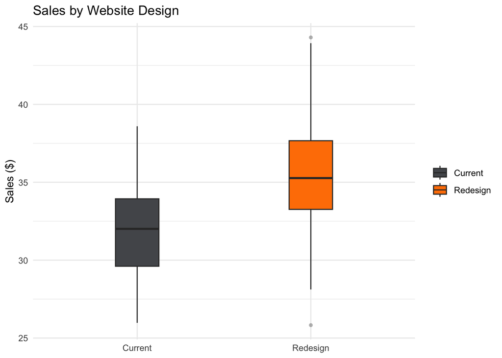

```r
dat <- dat %>%
  mutate(design = factor(design, levels = c(0,1), labels = c("Current","Redesign")))

ggplot(dat, aes(x = design, y = sales, fill = design)) +
  geom_boxplot(width = 0.25, outlier.shape = 16, outlier.alpha = 0.35) +
  scale_fill_manual(values = cat_pal) +
  labs(x = NULL, y = "Sales ($)", fill = NULL, title = "Sales by Website Design") +
  theme_minimal()
```

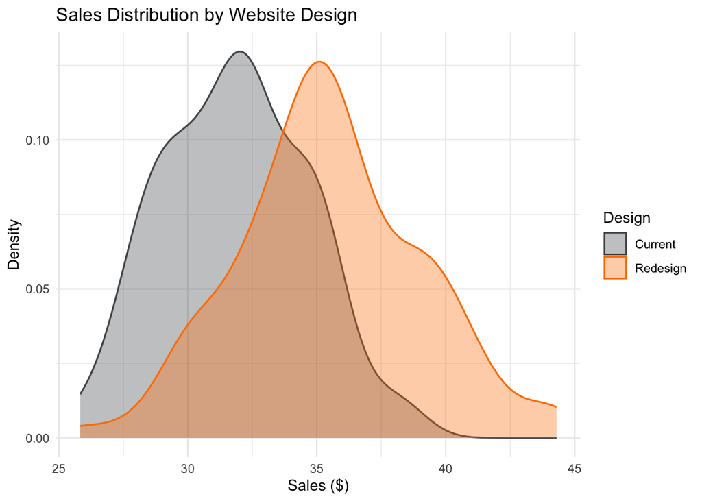

```r
ggplot(dat, aes(x = sales, fill = design, color = design)) +
  geom_density(alpha = 0.35, linewidth = 0.6) +
  scale_fill_manual(values = cat_pal) +
  scale_color_manual(values = cat_pal) +
  labs(title = "Sales Distribution by Website Design",
       x = "Sales ($)", y = "Density", fill = "Design", color = "Design") +
  theme_minimal()
```

Regarding the distribution of sales for the current design, the distribution clusters more tightly around the $30–34 range, with the peak density near around $32. For the redesign, the sales distribution shifts noticeably to the right. The peak is closer to $35–36, and the curve stretches further into higher values of $40 and more. This indicates that under the redesigned site, customers are making larger purchases on average, and the spread is wider (more variation in sales amounts). The redesign clearly generates more transactions in the upper-end tail of sales.

```r
cur <- subset(dat, design == "Current")$sales
new <- subset(dat, design == "Redesign")$sales

mean_current  <- mean(cur)
mean_redesign <- mean(new)
obs_diff    <- mean_redesign - mean_current

mean_current; mean_redesign; obs_diff
```

```
## [1] 31.84819
```

```
## [1] 35.51309
```

```
## [1] 3.664904
```

```r
tt <- t.test(new, cur, alternative = "greater", mu = 1.80, var.equal = FALSE)
tt
```

```
##
##  Welch Two Sample t-test
##
## data:  new and cur
## t = 4.1499, df = 186.01, p-value = 2.528e-05
## alternative hypothesis: true difference in means is greater than 1.8
## 95 percent confidence interval:
##  2.922037      Inf
## sample estimates:
## mean of x mean of y
##  35.51309  31.84819
```

## Alternate Statement

The observed difference in the data reflects seasonal demand or short-term promotions during the partial redesign window. In a normal period without those boosts, the true mean difference would be less than $1.80.